# Lecture 16: Sampling

Associated Textbook Section: [10.0](https://ccsf-math-108.github.io/textbook/chapters/10/Sampling_and_Empirical_Distributions.html)

## Outline

- Sampling
- Sampling with Technology

## Set Up the Notebook

```python
from datascience import *
import numpy as np
%matplotlib inline
import matplotlib.pyplot as plt
plt.style.use('fivethirtyeight')
```

## Sampling

### Random Samples

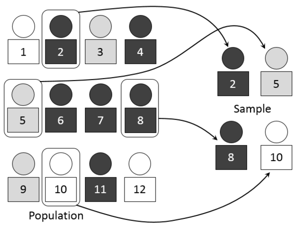

- Population: Set of all elements from whom a sample will be drawn
- Deterministic sample: The sampling scheme doesn't involve chance
- Random (Probability) sample:
  - Before the sample is drawn, you have to know the selection probability of every group of people in the population
  - Not all individuals/groups have to have an equal chance of being selected
  - If the chances are equal, then the sample is a simple random sample.

### Sample of Convenience

- Example: sample consists of whoever walks by
- Just because you think you're sampling "randomly", doesn't mean you have a random sample.
- If you can't figure out the following ahead of time, then you don't have a random sample
  - what's the population
  - what's the chance of selection, for each group in the population

### With and Without Replacement

[figure not shown]

- Sampling with Replacement:
  - One event happening does not impact the chance of another event happening
  - Associated with the concept called independent events.
- Sampling without Replacement:
  - One event happening may impact the chance of another event happening
  - Associated with the concept called dependent events.

## Sampling with Technology

### Sampling from Arrays and Tables

- Sampling from a table
  - Use can use `take` to systematically sample data from a table
  - `tbl.sample(k=n, with_replacement=True)`:
    - Randomly samples with replacement `n` rows from `tbl` and creates a new table
    - `k` is `tbl.num_rows` by default
    - `with_replacement` is `True` by default
- Sampling from an array
  - `np.random.choice(a=an_array, size=n, replace=True)`:
    - Randomly samples with replacement `n` elements from the elements in `an_array`
    - `size` is 1 by default
    - `replace` is `True` by default

### Demo: Sampling from Arrays and Tables

[figure not shown]

Load the November 2023 flight delay data in `delay.csv` sourced from the [Bureau of Transportation Statistic's Reporting Carrier On-Time Performance Data](https://www.transtats.bts.gov/DL_SelectFields.aspx?gnoyr_VQ=FGJ&QO_fu146_anzr=b0-gvzr). The variable `ARR_DELAY` contains the difference in minutes between scheduled and actual arrival time at the destination airport `DEST`. Early arrivals show negative numbers, and the airline code is expressed in the variable `OP_CARRIER`.

```python
delays = Table.read_table('delays.csv')
delays
```

| FL_DATE | OP_CARRIER | ORIGIN | DEST | ARR_DELAY |
| --- | --- | --- | --- | --- |
| 11/1/2023 12:00:00 AM | 9E | ABE | ATL | -22 |
| 11/1/2023 12:00:00 AM | 9E | ABE | ATL | -7 |
| 11/1/2023 12:00:00 AM | 9E | ABY | ATL | -21 |
| 11/1/2023 12:00:00 AM | 9E | ABY | ATL | -11 |
| 11/1/2023 12:00:00 AM | 9E | AEX | ATL | -27 |
| 11/1/2023 12:00:00 AM | 9E | AEX | ATL | -10 |
| 11/1/2023 12:00:00 AM | 9E | AGS | ATL | -18 |
| 11/1/2023 12:00:00 AM | 9E | AGS | ATL | -15 |
| 11/1/2023 12:00:00 AM | 9E | ALB | DTW | -13 |
| 11/1/2023 12:00:00 AM | 9E | ALB | LGA | -15 |

... (563767 rows omitted)

Demonstrate how to use the `take` method to sample the data in a few ways.

```python
delays.take(make_array(34, 221, 4040))
```

| FL_DATE | OP_CARRIER | ORIGIN | DEST | ARR_DELAY |
| --- | --- | --- | --- | --- |
| 11/1/2023 12:00:00 AM | 9E | ATL | HPN | -15 |
| 11/1/2023 12:00:00 AM | 9E | EWR | CVG | -27 |
| 11/1/2023 12:00:00 AM | B6 | BOS | RSW | 7 |

```python
delays.take(np.arange(0, delays.num_rows, 10_000))
```

| FL_DATE | OP_CARRIER | ORIGIN | DEST | ARR_DELAY |
| --- | --- | --- | --- | --- |
| 11/1/2023 12:00:00 AM | 9E | ABE | ATL | -22 |
| 11/1/2023 12:00:00 AM | OO | COS | ORD | -7 |
| 11/2/2023 12:00:00 AM | AA | DFW | MSP | -7 |
| 11/2/2023 12:00:00 AM | OO | MBS | DTW | -19 |
| 11/3/2023 12:00:00 AM | AA | DFW | VPS | -8 |
| 11/3/2023 12:00:00 AM | OO | ORD | JFK | -15 |
| 11/4/2023 12:00:00 AM | AA | MIA | TPA | -14 |
| 11/4/2023 12:00:00 AM | UA | LAX | SEA | 3 |
| 11/5/2023 12:00:00 AM | DL | BOI | ATL | -39 |
| 11/5/2023 12:00:00 AM | WN | BWI | TPA | -11 |

... (47 rows omitted)

```python
start = np.random.choice(np.arange(10_000))
start
```

```
7725
```

```python
systematic_sample = delays.take(np.arange(start, delays.num_rows, 10_000))
systematic_sample.show()
```

| FL_DATE | OP_CARRIER | ORIGIN | DEST | ARR_DELAY |
| --- | --- | --- | --- | --- |
| 11/1/2023 12:00:00 AM | HA | LIH | HNL | -6 |
| 11/1/2023 12:00:00 AM | YX | BOS | JFK | 0 |
| 11/2/2023 12:00:00 AM | NK | ATL | BWI | -4 |
| 11/2/2023 12:00:00 AM | YX | EWR | CLE | -30 |
| 11/3/2023 12:00:00 AM | NK | FLL | PHL | -32 |
| 11/3/2023 12:00:00 AM | YX | LGA | IND | -15 |
| 11/4/2023 12:00:00 AM | OO | GEG | LAX | 18 |
| 11/5/2023 12:00:00 AM | AA | SDF | CLT | -11 |
| 11/5/2023 12:00:00 AM | UA | DEN | SNA | -17 |
| 11/6/2023 12:00:00 AM | AS | SEA | ANC | 13 |
| 11/6/2023 12:00:00 AM | UA | IAD | SFO | -5 |
| 11/7/2023 12:00:00 AM | B6 | BOS | LAX | 16 |
| 11/7/2023 12:00:00 AM | WN | AUS | RDU | -1 |
| 11/8/2023 12:00:00 AM | DL | CLT | MSP | 0 |
| 11/8/2023 12:00:00 AM | WN | HNL | LIH | -14 |
| 11/9/2023 12:00:00 AM | DL | MIA | LAX | -19 |
| 11/9/2023 12:00:00 AM | WN | HOU | MIA | 16 |
| 11/10/2023 12:00:00 AM | DL | MSP | JAX | -17 |
| 11/10/2023 12:00:00 AM | WN | LAS | DAL | 4 |
| 11/11/2023 12:00:00 AM | F9 | PNS | DEN | 7 |
| 11/12/2023 12:00:00 AM | 9E | DHN | ATL | -12 |
| 11/12/2023 12:00:00 AM | NK | SEA | LAS | -6 |
| 11/13/2023 12:00:00 AM | 9E | SYR | LGA | 14 |
| 11/13/2023 12:00:00 AM | OH | DCA | MKE | 17 |
| 11/14/2023 12:00:00 AM | AA | CHS | CLT | -4 |
| 11/14/2023 12:00:00 AM | OO | LNK | ORD | -18 |
| 11/15/2023 12:00:00 AM | AA | MCO | CLT | -12 |
| 11/15/2023 12:00:00 AM | UA | CLE | SFO | -28 |
| 11/16/2023 12:00:00 AM | AS | ANC | FAI | 26 |
| 11/16/2023 12:00:00 AM | UA | DEN | ORD | -13 |
| 11/17/2023 12:00:00 AM | AS | FLL | SFO | 23 |
| 11/17/2023 12:00:00 AM | UA | DEN | SLC | -15 |
| 11/18/2023 12:00:00 AM | AS | STL | SEA | -2 |
| 11/18/2023 12:00:00 AM | WN | BHM | DAL | -19 |
| 11/19/2023 12:00:00 AM | DL | LAX | BNA | -29 |
| 11/19/2023 12:00:00 AM | WN | FAT | LAS | 162 |
| 11/20/2023 12:00:00 AM | DL | MSP | CVG | 42 |
| 11/20/2023 12:00:00 AM | WN | LAS | MKE | 3 |
| 11/21/2023 12:00:00 AM | DL | SEA | DEN | 7 |
| 11/21/2023 12:00:00 AM | WN | MCI | MCO | 5 |
| 11/22/2023 12:00:00 AM | DL | SEA | MSP | 12 |
| 11/22/2023 12:00:00 AM | WN | LGB | SMF | 1 |
| 11/23/2023 12:00:00 AM | UA | DEN | ORD | -16 |
| 11/24/2023 12:00:00 AM | DL | RSW | ATL | -11 |
| 11/24/2023 12:00:00 AM | WN | PIT | MDW | -16 |
| 11/25/2023 12:00:00 AM | MQ | CLT | ATW | 7 |
| 11/25/2023 12:00:00 AM | YX | BOS | CMH | -16 |
| 11/26/2023 12:00:00 AM | MQ | DFW | BMI | 8 |
| 11/26/2023 12:00:00 AM | WN | SJC | SNA | -9 |
| 11/27/2023 12:00:00 AM | HA | AUS | HNL | 46 |
| 11/27/2023 12:00:00 AM | WN | SAN | LAS | -12 |
| 11/28/2023 12:00:00 AM | NK | MIA | DEN | -5 |
| 11/29/2023 12:00:00 AM | AA | CAE | DFW | -7 |
| 11/29/2023 12:00:00 AM | OO | SMF | LAX | -13 |
| 11/30/2023 12:00:00 AM | AA | SRQ | PHL | 1 |
| 11/30/2023 12:00:00 AM | UA | IAH | IAD | 8 |

Demonstrate how to get a simple random sample of 12 flight delays using `np.random.choice` and `sample`.

```python
delays_arr = delays.column('ARR_DELAY')
delays_arr
```

```
array([-22.,  -7., -21., ..., -25., -19.,  -5.])
```

```python
np.random.choice(delays_arr, 12, replace=False)
```

```
array([  12.,  -23.,  128.,  -44.,  -22.,   -9.,    2.,  -10.,    8.,
        -14.,  -19.,  -31.])
```

```python
np.random.choice(delays_arr, 12, replace=True)
```

```
array([   1.,  -27.,  -23.,  -16.,   -6.,  -12.,  103.,   -8.,  210.,
          1.,  -19.,   -3.])
```

```python
random_sample = delays.sample(12, with_replacement=False)
random_sample.show()
```

| FL_DATE | OP_CARRIER | ORIGIN | DEST | ARR_DELAY |
| --- | --- | --- | --- | --- |
| 11/20/2023 12:00:00 AM | OO | SGU | SLC | -6 |
| 11/15/2023 12:00:00 AM | WN | PHX | SJC | -15 |
| 11/6/2023 12:00:00 AM | OH | LEX | CLT | -29 |
| 11/22/2023 12:00:00 AM | WN | TUS | LAX | -16 |
| 11/15/2023 12:00:00 AM | DL | SLC | SEA | -13 |
| 11/29/2023 12:00:00 AM | YX | LGA | CHO | -27 |
| 11/27/2023 12:00:00 AM | OO | PHX | IDA | -5 |
| 11/17/2023 12:00:00 AM | WN | JAX | ATL | -3 |
| 11/10/2023 12:00:00 AM | WN | SAN | DEN | 33 |
| 11/22/2023 12:00:00 AM | WN | SFO | LAS | -16 |
| 11/11/2023 12:00:00 AM | UA | SAN | SFO | -26 |
| 11/18/2023 12:00:00 AM | AA | CLT | DCA | 0 |

```python
random_sample = delays.sample(12, with_replacement=False)
random_sample.show()
```

| FL_DATE | OP_CARRIER | ORIGIN | DEST | ARR_DELAY |
| --- | --- | --- | --- | --- |
| 11/20/2023 12:00:00 AM | WN | LAS | STL | 28 |
| 11/25/2023 12:00:00 AM | OH | MYR | CLT | -30 |
| 11/27/2023 12:00:00 AM | WN | DEN | COS | 8 |
| 11/22/2023 12:00:00 AM | MQ | DFW | CLL | -7 |
| 11/1/2023 12:00:00 AM | OO | DEN | LBB | -12 |
| 11/19/2023 12:00:00 AM | AA | CLT | LAX | -28 |
| 11/10/2023 12:00:00 AM | AS | SEA | GEG | 47 |
| 11/15/2023 12:00:00 AM | UA | ORD | ICT | -15 |
| 11/8/2023 12:00:00 AM | OO | SLC | PHX | -11 |
| 11/16/2023 12:00:00 AM | OO | PSP | SFO | 4 |
| 11/20/2023 12:00:00 AM | AA | BWI | DFW | 30 |
| 11/15/2023 12:00:00 AM | DL | DCA | MSP | -7 |

## Attribution

This content is licensed under the Creative Commons Attribution-NonCommercial-ShareAlike 4.0 International License (CC BY-NC-SA 4.0) and derived from the Data 8: The Foundations of Data Science offered by the University of California, Berkeley.